# Project Draft

2023-11-22

### Introduction

We decided to focus project on NYC prison population due to the fact that females have become the fastest-growing segment of the incarcerated population with 15% growth, while male’s jail populations actually fell 9 percent from 2008 to 2018 ([^1]). This article made us curious about whether there is currently a difference between the proportions of males and females in the maximum custody level in New York prisons, which predominantly predicts the risk of escape, violence and dangerousness. Considering the considerable growth in female’s jail population, we predict that currently there is difference in proportions of males and females in the highest custody level in NYC prisons.

### Background

This data set contains information about inmates in custody at New York City prisons on a particular day. It includes a variety of demographic information about inmates(age, race, gender, etc.) as well as basic information about the inmate’s stay in prison (intake date, discharge date, custody level, etc.) This data set includes data on prisoners from all NYC jails under the oversight of NYC Department of Corrections, this includes the facilitates: Elmhurst Hospital Prison Ward, the Metropolitan Correction Center, Rikers Island and the Vernon C. Bain Correctional Center.It should be noted that this sample does not include all inmates from NYC prisons as it excludes closed cases. This data set is updated daily to reflect the current population of prisoners in NYC jails. This means that means different inmates are included in the data set daily as inmates are being discharged and admitted. Every row represents an inmate and their corresponding information

Who collected the data: NYC Department of Corrections Data source: NYC Open Data ([^2])

Variables: INMATEID: a unique 8-digit integer identification code for each inmate in the data set. By counting the number of inmate IDs present in a sample you can sum the population. It will be used in our data to calculate the population being held in maximum custody and the overall population of the sample. These two values will be used in calculating our population portion from our inference question. Thus, this value plays a key role in our final calculations. CUSTODY_LEVEL: a categorical variable representing the current custody level the inmate is being held in. Divided into three levels “min” for minimum, “med” for medium, and “max” for maximum. Whether an inmate is in max custody or not will affect whether they are included in the population sum of inmates being held in max custody. Thus this information affects the final population totals which determines the value of our population proportion. GENDER: A categorical variable representing the gender of a particular inmate. Stores value “M” if the inmate is male and “F” if the inmate is female. However, inmates with an NA value for gender will not be included in our population proportion.

One unusual factor to note is that this data set is updated daily, which means the proportions of males and females in each custody level might differ depending on the day. Our binomial model assumes that the sample taken from a single day can be representative of the prison population of any day within a reasonable amount of time, however, there are external variables dependent on days of the year that may effect these proportions. This might affect the validity of interpretations regarding the difference in proportions of males and females in each custody level.

In the rest of the report we intend to:

1. Compare the total number of males and females in the prison population sample
2. Compare the numbers of inmates in each custody level for each gender
3. Test our prediction, we will carry out a hypothesis test (two-sided binomial test) to check whether there is any difference in proportions of males and females in the Maximum custody level.

### Analysis

#### Exploration of Data

Let’s begin by examining the number of inmates of each gender in NYC prisons. The number of female inmates and the number of male inmates respectively will serve as the denominator of the population proportion for each of their respective population proportions. Through this exploration of the data, we found that there are 352 female inmates with a custody-level value that is not NA, and 5723 male inmates with a custody-level value that is not NA.

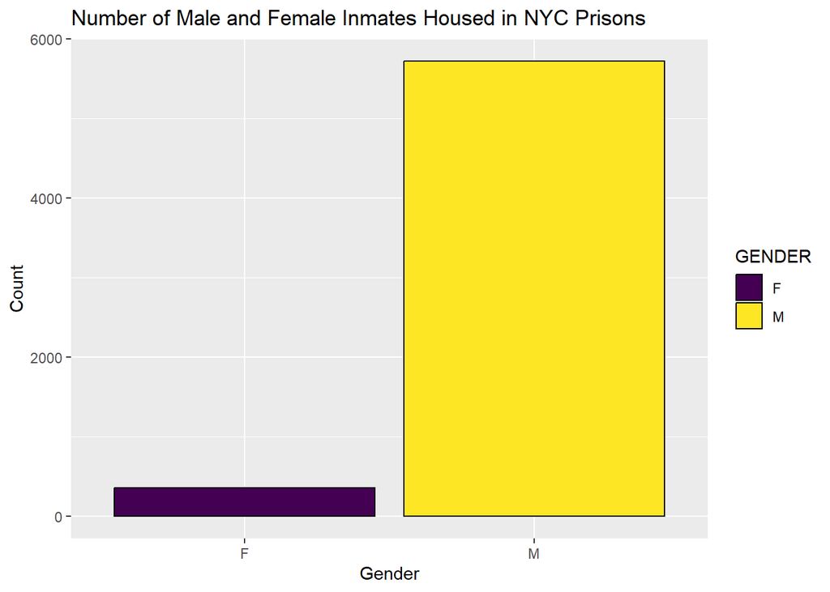

```
## # A tibble: 2 × 2
##   GENDER total_pop
##   <chr>      <int>
## 1 F            352
## 2 M           5723
```

Now let’s analyze the number of individuals in each custody level for each gender. The number of each gender being held in maximum custody will serve and the numerator of our population proportion. These graphs visualize that there are 117 female inmates and 1615 male inmates in the max custody level.

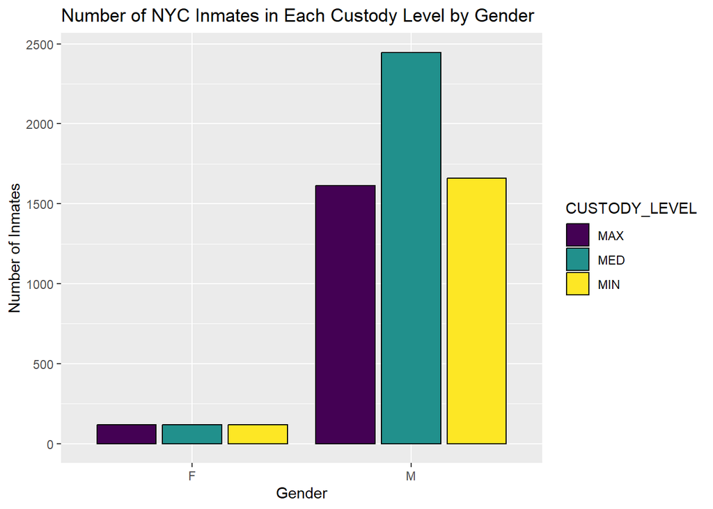

```
## # A tibble: 2 × 4
##   GENDER CUSTODY_LEVEL level_pop total_gender
##   <chr>  <chr>             <int>        <int>
## 1 F      MAX                 117          352
## 2 M      MAX                1615         5723
```

Now that we have both the numerator and denominator of our population proportion, lets visualize the proportion of each gender being held in the max custody level in NYC prisons. This graph demonstrates that there is about a 5% difference between the 2 proportions. This is a large difference in the two proportions considering the sample size of thousand of inmates. Since this is a notable difference between the two population proportions, this supports are final conclusion to reject the null hypothesis, meaning the population proportions are different, however, we will perform a 2 sided binomial hypothesis test to test this prediction.

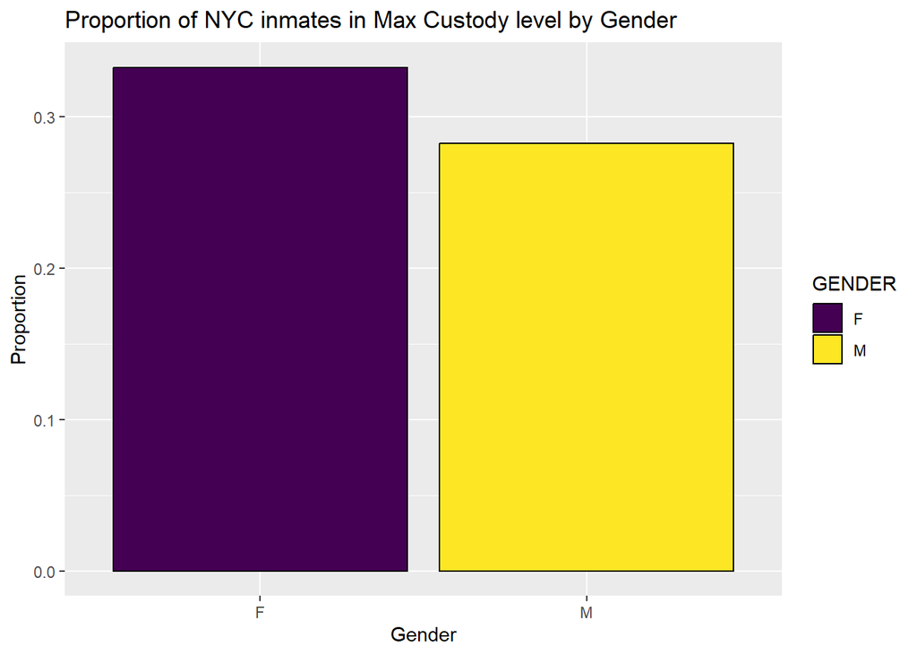

```
## # A tibble: 2 × 3
##   GENDER CUSTODY_LEVEL  prop
##   <chr>  <chr>         <dbl>
## 1 F      MAX           0.332
## 2 M      MAX           0.282
```

#### Numerical Analysis on Inference Question

The question of interest we are answering is: is there a difference between the proportions of males and females in the highest custody level in NYC prisons?

We will conduct a hypothesis test to determine whether there is a difference between the true proportions of males and females in the highest custody level in NYC prisons. The null hypothesis will be (H0: p1=p2), while the alternate hypothesis will be Ha: p1!=p2.

The binomial model we will be using to represent this is:

X1 | p1 ~ Binomial(number of males in the sample, p1) X2 | p2 ~ Binomial(number of females in the sample, p2)

For the binomial distribution being in the MAX custody level is considered “success”, while not being in MAX custody level is “failure”

p1 is the probability that a male in NYC prison is under the highest custody level, it equals 0.282

p2 is the probability that a female in NYC prison is under the highest custody level, it equals 0.332

```r
PE = p1-p2
print(PE)
```

```
## [1] -0.05019171
```

In the sample we observe that the proportion of males in MAX custody level is lower than the proportion of females by around 5%

Now we will calculate the standard error of point estimate. We will calculate this through the standard error formula for differences of proportions.

```r
SE = sqrt(((p1 * (1-p1)) / n1) + ((p2 * (1-p2)) / n2))
print(SE)
```

```
## [1] 0.02580326
```

```r
Z = PE / (SE * PE)
print(Z)
```

```
## [1] 38.7548
```

```r
print((1 - pnorm(Z, 0, 1)) * 2)
```

```
## [1] 0
```

### Discussion

#### Possible Shortcomings

However, our analysis would not give the full picture of the population of prison inmates as a large number of prisoner records are sealed. If we had access to all prisoner records our conclusion in the proportions of males and females in max level custody may have been affected.

#### Potential Future Directions

##### New Question

A possible avenue for more analysis would be analyzing the economic standings(for ex: Higher Income, Middle Income, Lower Income) of the prison population and determining how much difference income level makes in the proportions of the prison population. We could then also see if gender combined with income causes proportion differences. For example: If females in the lower income category were more probable to end up in prison than males in the same income category.

Regarding the proportions of males in females in different custody levels, we could also check whether there is a significant difference in proportions of males and females in medium and minimum custody level.

##### Different methods to address the same questions

Our primary question of male and female population proportions being affected by gender could also be portrayed using a confidence interval. We would do this by finding the sample mean and standard deviation of our point estimate values(p-hat values for gender) Then we would set a confidence interval of say 99%, that the difference in proportion of males and females in max custody lies between a certain ratio of values. Using the confidence interval we could determine between which values the true difference in proportions of males and females in the max custody level lies. This would ideally be done through a normal distribution since we have a relatively large number of values.

##### New data to improve understanding

If a data set had more variables such as economic well being(Higher Income, Middle Income, Lower Income), political leanings(Liberal, Central, Conservative), and ownership of lethal weapons(Yes, No) it would give us a greater idea of the various factors at play in determining the population of prisoners. For example: The reason that our null hypothesis was false could have been the fact that there is a great difference in the number of males and females who are of conservative political leaning, which happens to be the most significant factor in determining whether someone is in maximum custody or not.

### References

[^1]: https://www.vera.org/news/womens-incarceration-rates-are-skyrocketing#:~:text=Women%20have%20become%20the%20fastest,state%20prisons%20across%20the%20country.
[^2]: https://data.cityofnewyork.us/Public-Safety/Daily-Inmates-In-Custody/7479-ugqb